# **FIVB Beach Volleyball Historic Top 8 Teams Analysis**

### **Tyler Widdison**

# Mean of matches played and won from the top 8 teams considering 2001 - 2019.

### **Men**

#### There has been a downward trend of top 8 mens teams playing matches per year with 2017 being the lowest. Avg matches played for mens top 8 in a FIVB season is 57.59 and wins is 41.04 from 2001 - 2019.

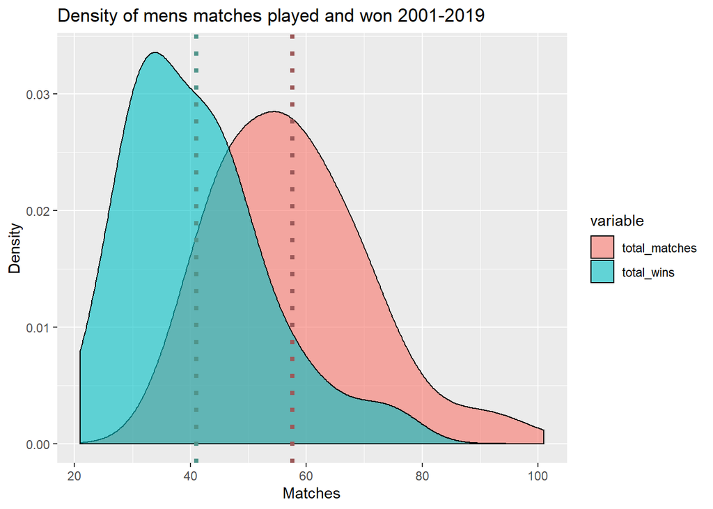

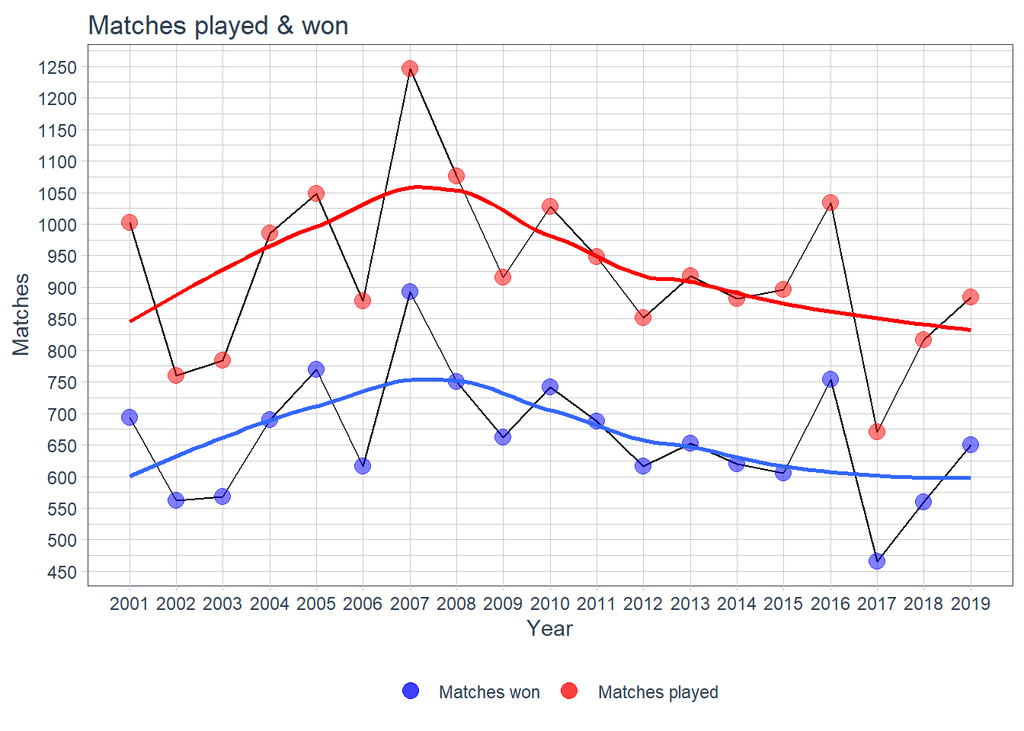

### **Women**

#### There has been a slight downward trend of top 8 womens teams playing matches per year with the lowest being 2004. The avg matches played for womens top 8 in a FIVB season is 59.8 and matches won 43.54 from 2001 - 2019.

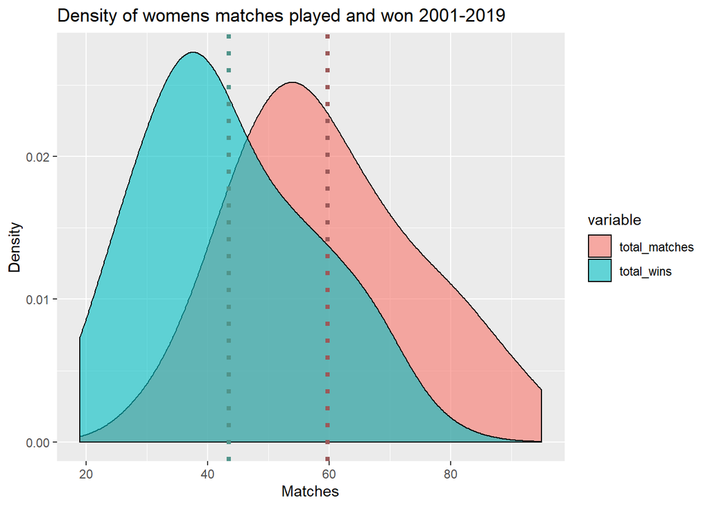

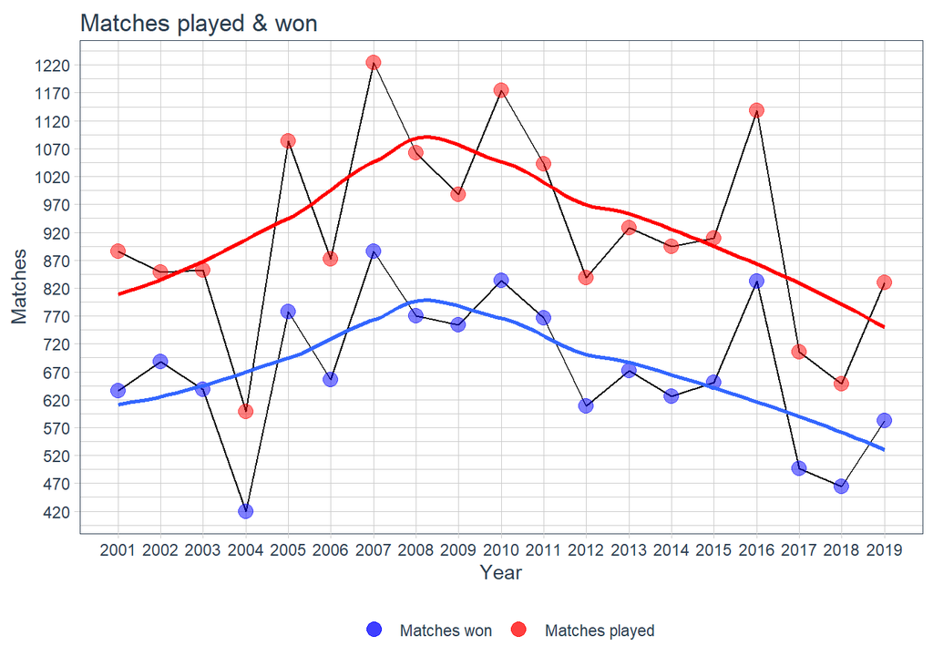

# Courts match’s were played by a team in the top 8.

### **Men**

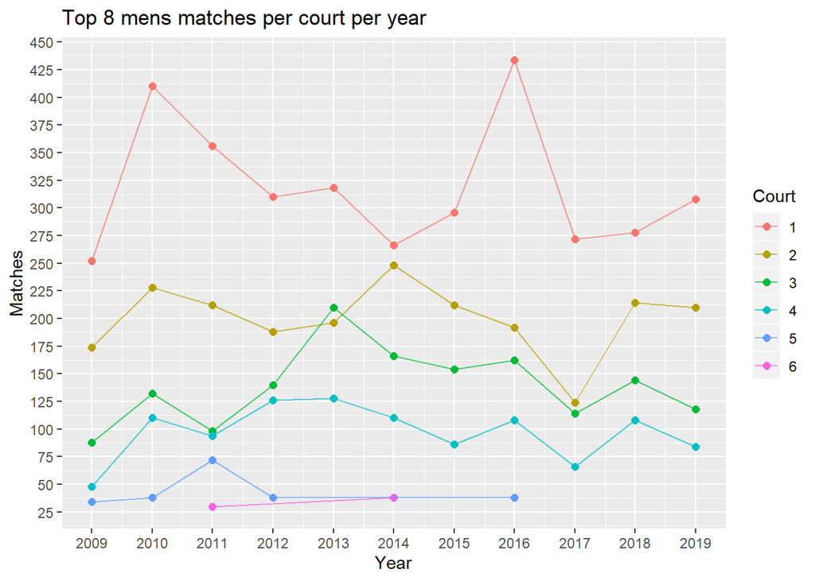

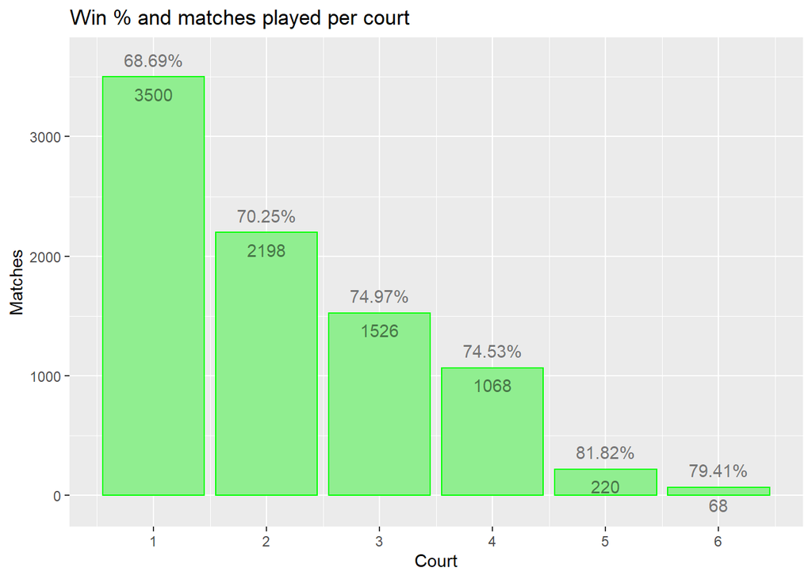

### **Women**

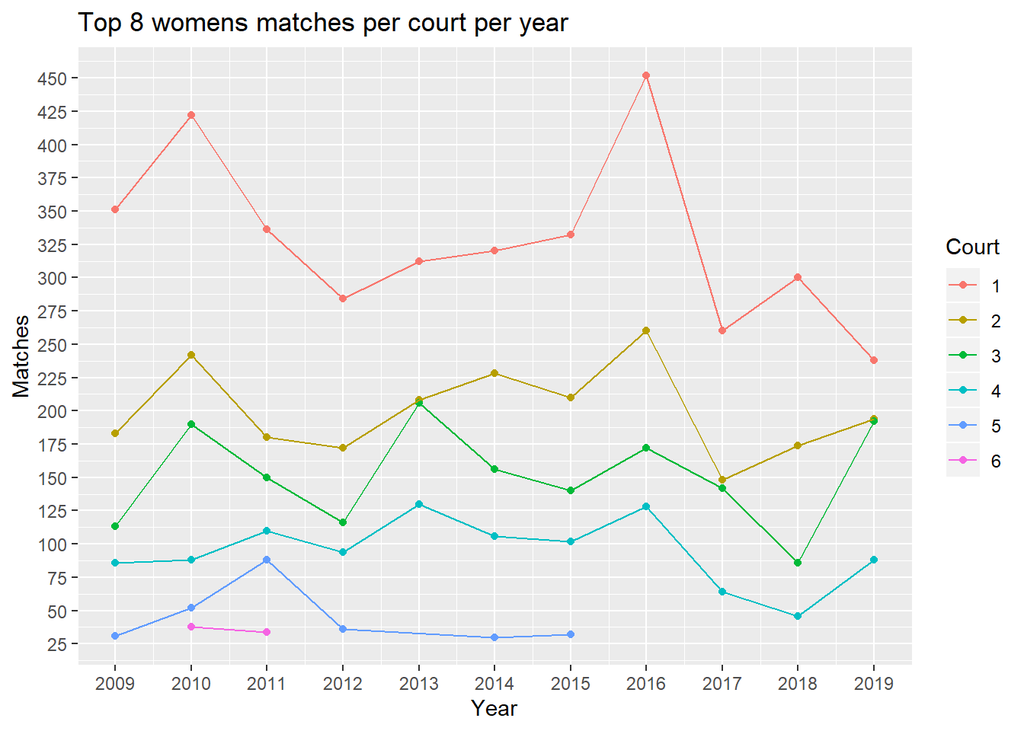

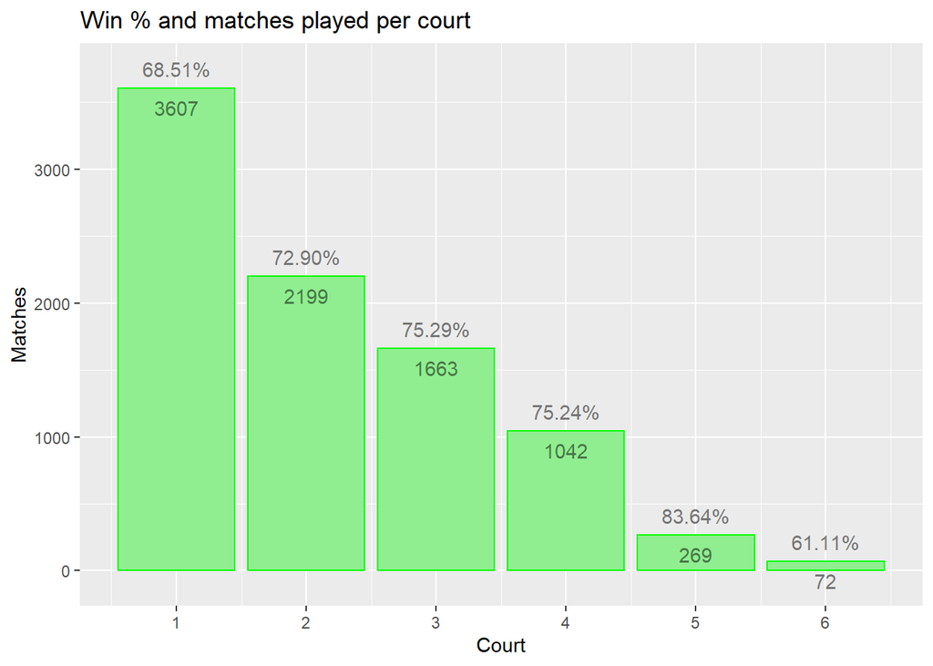

# Hour of day match’s were played by a team in the top 8.

### **Men**

#### Matches played by hour by mens teams in top 8 from 2004-2019. The lowest winning percentage by a team in the top 8 is 21:00. And the highest is at 08:00.

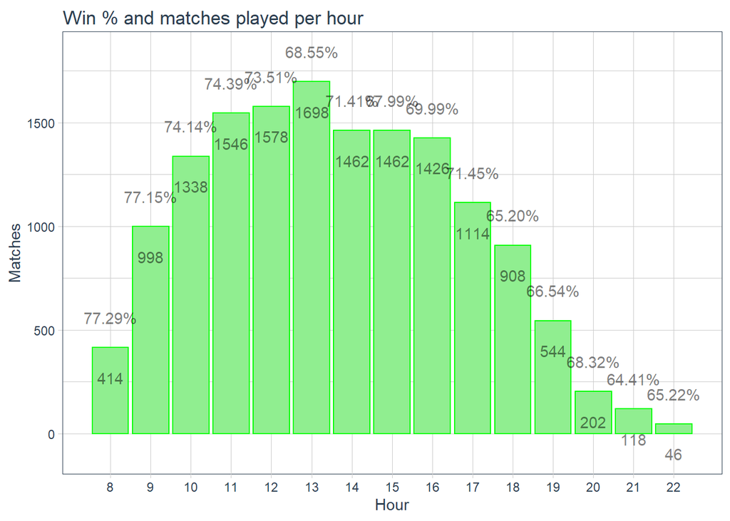

### **Women**

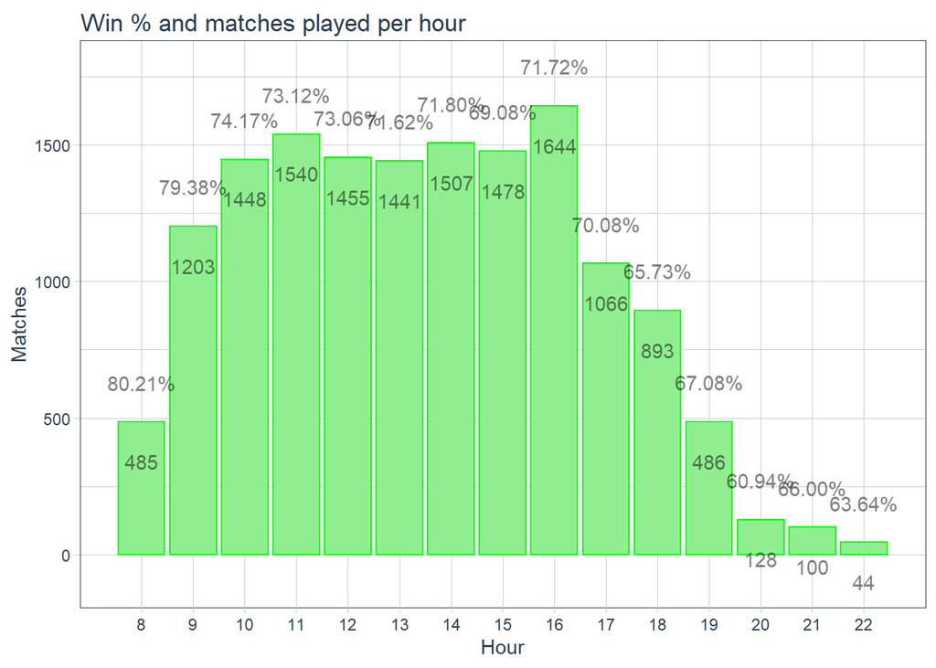

# Match win % per hour and court trend by mens teams in top 8 from 2009-2019.

### **Men**

#### This data only takes into account when the court and time were present. The highest winning % is court 5 at 12:00. The lowest winning % is court 1 at 20:00.

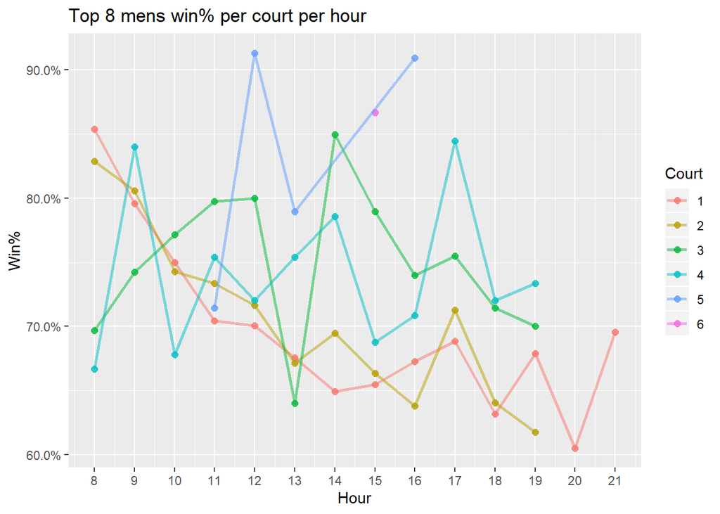

### **Women**

#### This data only takes into account when the court and time were present. The highest winning % is court 5 at 09:00 and 12:00. The lowest winning % is court 1 at 20:00.

[figure not shown]

# Probability of winning by court and hour using Generalized linear regression.

### **Men**

#### The highest probability for a men’s team to win in the top 8 is court 5 at 11:00. With the loweset being at 21:00 on court 1.

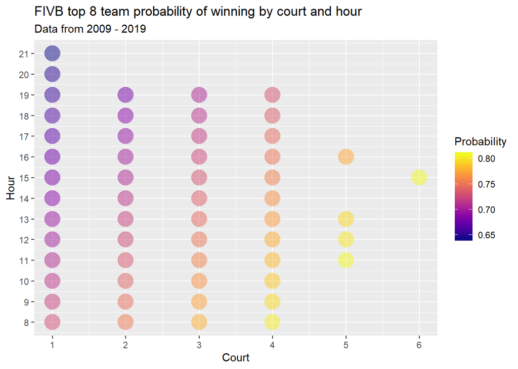

| Hour | Court | Probablity |
| --- | --- | --- |
| 11 | 5 | 0.808 |
| 15 | 6 | 0.806 |
| 8 | 4 | 0.803 |
| 12 | 5 | 0.801 |
| 9 | 4 | 0.796 |
| 13 | 5 | 0.795 |
| 10 | 4 | 0.790 |
| 11 | 4 | 0.783 |
| 8 | 3 | 0.778 |
| 12 | 4 | 0.777 |
| 16 | 5 | 0.775 |
| 9 | 3 | 0.772 |
| 13 | 4 | 0.770 |
| 10 | 3 | 0.765 |
| 14 | 4 | 0.764 |
| 11 | 3 | 0.758 |
| 15 | 4 | 0.757 |
| 8 | 2 | 0.753 |
| 12 | 3 | 0.752 |
| 16 | 4 | 0.750 |
| 9 | 2 | 0.747 |
| 13 | 3 | 0.745 |
| 17 | 4 | 0.744 |
| 10 | 2 | 0.740 |
| 14 | 3 | 0.739 |
| 18 | 4 | 0.737 |
| 11 | 2 | 0.734 |
| 15 | 3 | 0.732 |
| 19 | 4 | 0.731 |
| 8 | 1 | 0.729 |
| 12 | 2 | 0.727 |
| 16 | 3 | 0.726 |
| 9 | 1 | 0.722 |
| 13 | 2 | 0.721 |
| 17 | 3 | 0.719 |
| 10 | 1 | 0.715 |
| 14 | 2 | 0.714 |
| 18 | 3 | 0.713 |
| 11 | 1 | 0.709 |
| 15 | 2 | 0.707 |
| 19 | 3 | 0.706 |
| 12 | 1 | 0.702 |
| 16 | 2 | 0.701 |
| 13 | 1 | 0.696 |
| 17 | 2 | 0.694 |
| 14 | 1 | 0.689 |
| 18 | 2 | 0.688 |
| 15 | 1 | 0.683 |
| 19 | 2 | 0.681 |
| 16 | 1 | 0.676 |
| 17 | 1 | 0.670 |
| 18 | 1 | 0.663 |
| 19 | 1 | 0.656 |
| 20 | 1 | 0.650 |
| 21 | 1 | 0.643 |

### **Women**

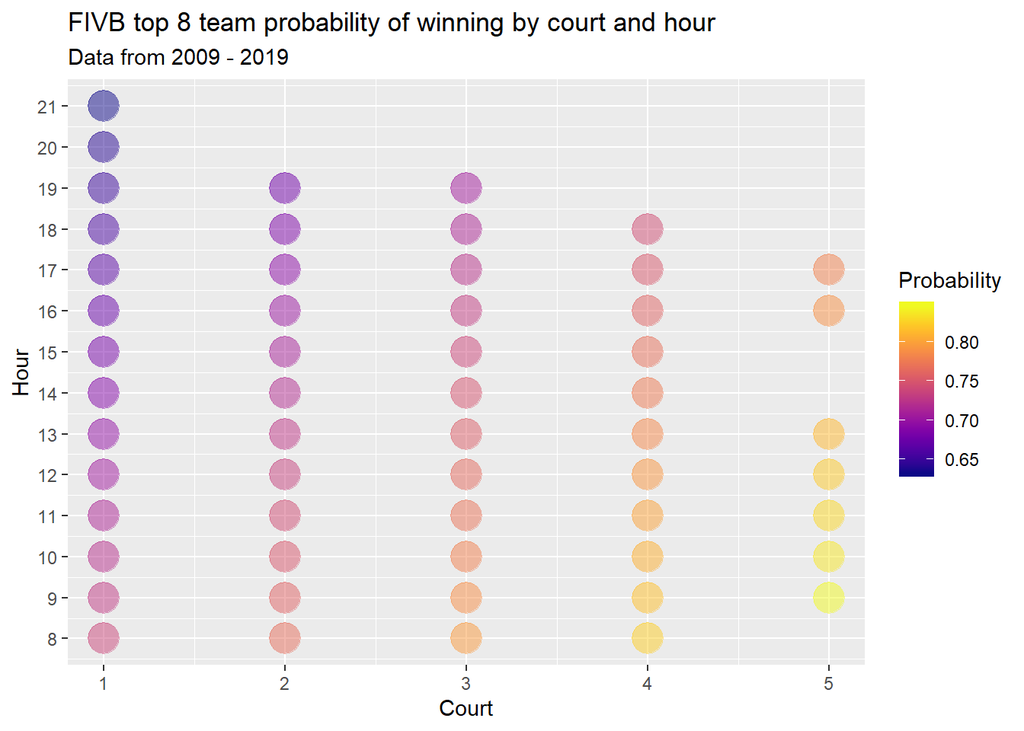

| Hour | Court | Probablity |
| --- | --- | --- |
| 9 | 5 | 0.846 |
| 10 | 5 | 0.838 |
| 11 | 5 | 0.830 |
| 8 | 4 | 0.825 |
| 12 | 5 | 0.822 |
| 9 | 4 | 0.817 |
| 13 | 5 | 0.813 |
| 10 | 4 | 0.809 |
| 11 | 4 | 0.801 |
| 8 | 3 | 0.796 |
| 12 | 4 | 0.793 |
| 16 | 5 | 0.789 |
| 9 | 3 | 0.788 |
| 13 | 4 | 0.785 |
| 17 | 5 | 0.781 |
| 10 | 3 | 0.780 |
| 14 | 4 | 0.776 |
| 11 | 3 | 0.772 |
| 15 | 4 | 0.768 |
| 8 | 2 | 0.767 |
| 12 | 3 | 0.764 |
| 16 | 4 | 0.760 |
| 9 | 2 | 0.759 |
| 13 | 3 | 0.756 |
| 17 | 4 | 0.752 |
| 10 | 2 | 0.751 |
| 14 | 3 | 0.748 |
| 18 | 4 | 0.744 |
| 11 | 2 | 0.743 |
| 15 | 3 | 0.739 |
| 8 | 1 | 0.738 |
| 12 | 2 | 0.735 |
| 16 | 3 | 0.731 |
| 9 | 1 | 0.730 |
| 13 | 2 | 0.727 |
| 17 | 3 | 0.723 |
| 10 | 1 | 0.722 |
| 14 | 2 | 0.719 |
| 18 | 3 | 0.715 |
| 11 | 1 | 0.714 |
| 15 | 2 | 0.711 |
| 19 | 3 | 0.707 |
| 12 | 1 | 0.706 |
| 16 | 2 | 0.702 |
| 13 | 1 | 0.698 |
| 17 | 2 | 0.694 |
| 14 | 1 | 0.690 |
| 18 | 2 | 0.686 |
| 15 | 1 | 0.682 |
| 19 | 2 | 0.678 |
| 16 | 1 | 0.673 |
| 17 | 1 | 0.665 |
| 18 | 1 | 0.657 |
| 19 | 1 | 0.649 |
| 20 | 1 | 0.641 |
| 21 | 1 | 0.633 |

### *Conclusion*

#### There is an apparent trend of teams in the top 8 winning more and having higher probility of winning on lower courts earlier in the day. And lower probility later in the day on higher courts. This trend is likely due to teams in the top 8 advancing further into tournaments and playing other teams in the top 8.